# Notas de Clase: ¿Son distintos estos grupos?

## 5.4 «¿Entonces Antioquia también es distinta?»

**La secretaría pregunta:** *«Si sale real para nosotros, ¿qué pasa con un departamento grande?»*

Hagamos la misma cuenta con Antioquia.

```r
hotelling_1 <- function(Y, mu) {
  n <- nrow(Y); p <- ncol(Y); dif <- colMeans(Y) - mu
  D2 <- as.numeric(t(dif) %*% solve(cov(Y)) %*% dif)
  T2 <- n * D2; F <- (n - p) / (p * (n - 1)) * T2
  c(n = n, D = sqrt(D2), T2 = T2, F = F, p = pf(F, p, n - p, lower.tail = FALSE))
}
h_atl <- hotelling_1(Xa, mu)
h_ant <- hotelling_1(X[sc$depto == "ANTIOQUIA", ], mu)
dif_ant <- colMeans(X[sc$depto == "ANTIOQUIA", ]) - mu
signif(rbind(atlantico = h_atl, antioquia = h_ant), 4)
```

```
##              n      D     T2      F         p
## atlantico  610 0.4227 109.00 21.650 5.710e-20
## antioquia 1344 0.1345  24.33  4.851 2.112e-04
```

```r
round(dif_ant, 1)
```

```
## cuantitativo      lectura   ciudadanas       ingles    escritura
##         -0.6          1.1          0.0         -0.5          1.6
```

> 📋 **Describir:** Antioquia, con 1 344 estudiantes, está a 0,13 desviaciones del país: ningún módulo se aparta más de 1,6 puntos. Y aun así la probabilidad de que sea azar es una en 4 735: también sale **real**.

> 🔎 **Analizar:** con muchos estudiantes, el cálculo detecta hasta una diferencia de 1,6 puntos. **Es real, pero no es grande**: a ninguna secretaría le cambia una decisión. **Decisión:** en el informe nunca va solo «la diferencia es real». Va **cuánto** es. Si otro departamento presume de ser «distinto», la pregunta es: ¿a cuántas desviaciones?

## 5.5 «¿Todos nuestros estudiantes están por debajo?»

**La secretaría pregunta:** *«Si estamos abajo, ¿hay que reforzar a todos los estudiantes del departamento?»*

Que el **promedio** del Atlántico esté por debajo no dice que **cada** estudiante lo esté.

```r
mediana_pais <- median(sc$global)
sobre_mediana_atl <- 100 * mean(sc$global[atl] > mediana_pais)
cuantos_sobre <- sum(sc$global[atl] > mediana_pais)
c(mediana_global_pais = mediana_pais,
  atlantico_sobre_la_mediana = cuantos_sobre,
  de_cada_100 = round(sobre_mediana_atl, 1))
```

```
##        mediana_global_pais atlantico_sobre_la_mediana
##                      100.0                      192.0
##                de_cada_100
##                       31.5
```

Y uno de ellos, para que no sea una cifra abstracta: el estudiante **de estrato 1** del Atlántico con el mejor puntaje global.

```r
atl1 <- sc[atl & sc$estrato == "1", ]
mejor <- atl1[which.max(atl1$global), c(modulos, "global", "estrato")]
mejor
```

|  | cuantitativo | lectura | ciudadanas | ingles | escritura | global | estrato |
| --- | --- | --- | --- | --- | --- | --- | --- |
| 5838 | 123 | 130 | 130 | 142 | 113 | 128 | 1 |

```r
supera_al_pais <- 100 * mean(sc$global < mejor$global)
round(supera_al_pais, 1)
```

```
## [1] 96.9
```

> 📋 **Describir:** 192 estudiantes del Atlántico, 31,5 de cada 100, superan la mediana del país (100 puntos). Si el Atlántico fuera igual al país, serían 50. Uno de ellos es de estrato 1 y saca 128 de global, con 123 en cuantitativo y 142 en inglés: supera a 96,9 de cada 100 estudiantes del país.

> 🔎 **Analizar:** el grupo está **desplazado** hacia abajo, pero casi un tercio de sus estudiantes está en la mitad de arriba del país. **Diferencia no es separación.** **Decisión de la secretaría:** el resultado sirve para **diseñar un programa departamental** y para pedir recursos; **no** sirve para tratar a cada estudiante del Atlántico como si estuviera por debajo. Un programa para «todos» gastaría plata en estudiantes como el de la tabla.

## 5.6 «¿Es el departamento o es la pobreza?»

**La secretaría pregunta:** *«Antes de que el gobernador culpe a las instituciones: ¿no será que tenemos estudiantes más pobres?»* Es la pregunta de la **variable que viaja con el grupo**.

```r
comp <- rbind(
  atlantico = round(100 * prop.table(table(factor(sc$estrato[atl], levels = c("1", "2", "3", "4 a 6")))), 1),
  pais      = round(100 * prop.table(table(factor(sc$estrato, levels = c("1", "2", "3", "4 a 6")))), 1))
comp
```

```
##              1    2    3 4 a 6
## atlantico 49.8 36.3 10.7   3.3
## pais      29.2 43.6 23.8   3.3
```

```r
dentro <- sapply(c("1", "2", "3"), function(k)
  c(atlantico = mean(sc$global[atl & sc$estrato == k]), pais = mean(sc$global[sc$estrato == k])))
round(dentro, 1)
```

```
##              1     2     3
## atlantico 92.8  95.5  99.2
## pais      95.4 100.8 104.0
```

> 📋 **Describir:** en el Atlántico, 49,8 de cada 100 estudiantes son de estrato 1; en el país, 29,2. Pero **dentro del mismo estrato** el Atlántico sigue por debajo: en estrato 1, 92,8 contra 95,4; en estrato 2, 95,5 contra 100,8.

> 🔎 **Analizar:** parte de la brecha **viaja con el estrato**: el Atlántico tiene más estudiantes de estrato 1. Pero no es toda: comparando estudiantes del mismo estrato, la brecha sigue. **Decisión de la secretaría:** no puede decir «es por la pobreza» ni «es por nuestras instituciones»: hay algo de las dos. El programa necesita dos frentes, apoyo a los estudiantes de estratos bajos y revisión de las instituciones, y el informe lo dice así.

# 6 Segunda pregunta: «¿Hombres y mujeres llegan distintos al programa de orientación?»

Ahora no comparamos un grupo con el país: comparamos **dos grupos entre sí**. Usamos toda la base, porque el programa de orientación se va a diseñar con lo que se sabe de los técnicos del país.

## 6.1 «¿Uno de los dos va mejor?»

**La secretaría pregunta:** *«¿Hay que reforzar más a los hombres o a las mujeres?»*

```r
tapply(sc$global, sc$genero, mean) |> round(1)
```

```
##  Mujer Hombre
##   99.6  100.9
```

```r
table(sc$genero)
```

```
##
##  Mujer Hombre
##   5555   4352
```

Si solo miráramos el puntaje global, diríamos que no: la diferencia es de poco más de un punto. **No hay un sexo «que va peor».** Pero eso no responde si llegan **con lo mismo**.

## 6.2 «¿Llegan con las mismas fortalezas?»

**La secretaría pregunta:** *«Para orientar, no me importa solo el nivel: ¿en qué es fuerte cada uno?»*

```r
medias_g <- sapply(modulos, function(m) tapply(sc[[m]], sc$genero, mean))
dif_g <- medias_g["Hombre", ] - medias_g["Mujer", ]
round(rbind(medias_g, hombre_menos_mujer = dif_g), 1)
```

```
##                    cuantitativo lectura ciudadanas ingles escritura
## Mujer                      97.4   100.0      100.1   98.3     102.1
## Hombre                    103.5   100.2      100.2  102.4      98.1
## hombre_menos_mujer          6.1     0.2        0.1    4.1      -4.1
```

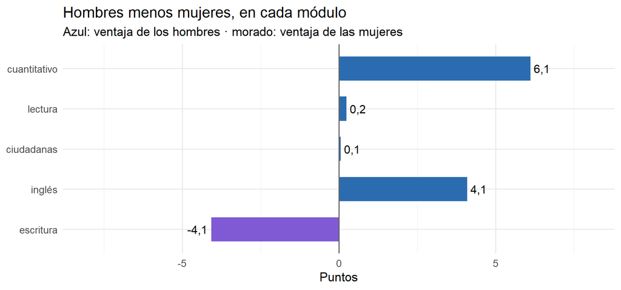

```r
data.frame(modulo = factor(etiqueta[modulos], levels = rev(etiqueta)), dif = dif_g) |>
  ggplot(aes(dif, modulo, fill = dif > 0)) +
  geom_col(width = 0.6) +
  geom_vline(xintercept = 0, color = "grey40") +
  geom_text(aes(label = coma(dif), hjust = ifelse(dif > 0, -0.2, 1.2)), size = 4.2) +
  scale_fill_manual(values = c("#805AD5", "#2B6CB0"), guide = "none") +
  scale_x_continuous(limits = c(-8, 8), labels = function(x) coma(x, 0)) +
  labs(title = "Hombres menos mujeres, en cada módulo",
       subtitle = "Azul: ventaja de los hombres · morado: ventaja de las mujeres", x = "Puntos", y = NULL)
```

Dos estudiantes reales con **el mismo puntaje global**, para verlo de cerca: entre los que sacaron exactamente 100 de global, el hombre con más ventaja de cuantitativo sobre escritura y la mujer con más ventaja de escritura sobre cuantitativo.

```r
g100 <- sc[sc$global == 100, ]
h <- g100[g100$genero == "Hombre", ]; h <- h[which.max(h$cuantitativo - h$escritura), ]
m <- g100[g100$genero == "Mujer", ];  m <- m[which.max(m$escritura - m$cuantitativo), ]
rbind(hombre = h[c(modulos, "global")], mujer = m[c(modulos, "global")])
```

|  | cuantitativo | lectura | ciudadanas | ingles | escritura | global |
| --- | --- | --- | --- | --- | --- | --- |
| hombre | 123 | 107 | 122 | 111 | 35 | 100 |
| mujer | 70 | 96 | 88 | 125 | 122 | 100 |

```r
c(con_global_100 = nrow(g100))
```

```
## con_global_100
##            261
```

> 📋 **Describir:** los hombres sacan en promedio 6,1 puntos más en cuantitativo y 4,1 más en inglés; las mujeres, 4,1 más en escritura. En lectura y ciudadanas la diferencia es menor de medio punto. Y los dos estudiantes de la tabla sacan los dos 100 de global: él, 123 en cuantitativo y 35 en escritura; ella, 70 y 122.

> 🔎 **Analizar:** **el nivel es el mismo, el perfil no.** Las ventajas se compensan, y por eso el global casi no cambia. Un informe que solo mire el global diría «no hay diferencia» y se perdería lo que le importa a un programa de orientación. Los dos estudiantes de la tabla son el caso extremo: el mismo número, dos personas que necesitan cosas opuestas. **Decisión de la secretaría:** el programa no se diseña con el puntaje global; se diseña con el perfil. Falta saber cuánto pesa esa diferencia de perfil.

## 6.3 «¿Cuánto pesa esa diferencia de perfil?»

**La secretaría pregunta:** *«¿Es una diferencia de verdad, o son unos pocos puntos?»*

Es la misma distancia de antes, ahora **entre los dos promedios**, y la misma pregunta de si puede ser azar.

```r
hotelling_2 <- function(A, B) {
  n1 <- nrow(A); n2 <- nrow(B); p <- ncol(A)
  Sp <- ((n1 - 1) * cov(A) + (n2 - 1) * cov(B)) / (n1 + n2 - 2)
  dif <- colMeans(A) - colMeans(B)
  D2 <- as.numeric(t(dif) %*% solve(Sp) %*% dif)
  T2 <- n1 * n2 / (n1 + n2) * D2
  F  <- (n1 + n2 - p - 1) / (p * (n1 + n2 - 2)) * T2
  c(D = sqrt(D2), T2 = T2, F = F, p = pf(F, p, n1 + n2 - p - 1, lower.tail = FALSE))
}
h_gen <- hotelling_2(X[sc$genero == "Hombre", ], X[sc$genero == "Mujer", ])
signif(h_gen, 4)
```

```
##          D         T2          F          p
##  4.909e-01  5.880e+02  1.176e+02 3.558e-121
```

```r
# comprobación: R lo calcula con manova(); debe dar el mismo resultado (T2)
L <- summary(manova(X ~ sc$genero), test = "Wilks")$stats[1, 2]
round((nrow(sc) - 2) * (1 / L - 1), 2)
```

```
## [1] 588.03
```

> 📋 **Describir:** los dos perfiles están a 0,49 desviaciones, y la probabilidad de que sea azar es menos de una en un millón. La comprobación con la función `manova()` de R da el mismo resultado.

> 🔎 **Analizar:** **es real**, sin ninguna duda, y **moderada**: casi media desviación, parecida a la del Atlántico. **Decisión de la secretaría:** la diferencia de perfil existe y es del mismo tamaño que la brecha del departamento: merece entrar al diseño del programa. Falta la tercera pregunta, que es la que más importa para orientar a una persona.

## 6.4 «Si me muestran los puntajes de alguien, ¿sé si es hombre o mujer?»

**La secretaría pregunta:** *«¿Podemos orientar a cada estudiante según su sexo?»*

Ésta es la prueba de fuego. Usamos los cinco puntajes para clasificar a cada estudiante como hombre o mujer, con la regla que mejor lo hace, y contamos los aciertos.

```r
clasif <- MASS::lda(sc[modulos], sc$genero)
acierto_gen <- 100 * mean(predict(clasif)$class == sc$genero)
sin_datos   <- 100 * max(table(sc$genero)) / nrow(sc)
c(acierto_con_los_cinco_puntajes = round(acierto_gen, 1),
  acierto_diciendo_siempre_mujer  = round(sin_datos, 1))
```

```
## acierto_con_los_cinco_puntajes acierto_diciendo_siempre_mujer
##                           61.8                           56.1
```

> 📋 **Describir:** con los cinco puntajes se acierta el sexo en 61,8 de cada 100 estudiantes. Diciendo siempre «mujer», sin mirar ningún puntaje, se acierta en 56,1.

> 🔎 **Analizar:** los puntajes mejoran el acierto en apenas 5,7 puntos. **La diferencia es real y los grupos no se separan**: hombres y mujeres se montan casi por completo. La pareja de la tabla anterior es un extremo escogido a propósito; la mayoría de los hombres y de las mujeres tienen perfiles que se confunden entre sí. **Decisión de la secretaría:** el perfil sirve para **prever la demanda** del programa —habrá más hombres pidiendo apoyo en escritura y más mujeres en cuantitativo—, pero **no justifica orientar a nadie según su sexo**. A cada estudiante se le orienta por **sus propios puntajes**.

**✋ **Deténgase aquí y responda:** el global de hombres y mujeres difiere en poco más de un punto, y la distancia de los cinco módulos es casi media desviación. ¿Cómo pueden ser verdad las dos cosas? *(Clic para ver la respuesta.)**

Porque las diferencias van **en direcciones contrarias**: los hombres ganan en cuantitativo e inglés y las mujeres en escritura. Al sumar los cinco módulos en el global, se cancelan. La distancia de los cinco al tiempo **no deja que se cancelen**: mide el perfil, no solo el nivel. Es lo mismo que pasa con los dos estudiantes que sacaron 100.

# 7 «¿Cómo se vería una diferencia que sí separa?»

**La secretaría pregunta:** *«Ustedes dicen que nuestras diferencias no separan. ¿Comparado con qué?»*

Para ver cómo se ve una separación de verdad, usamos **iris**: 50 flores de la especie *setosa* y 50 de *versicolor*, con cuatro medidas de sus pétalos y sépalos.

```r
ir <- droplevels(iris[iris$Species != "virginica", ])
h_iris <- hotelling_2(as.matrix(ir[ir$Species == "versicolor", 1:4]),
                      as.matrix(ir[ir$Species == "setosa", 1:4]))
acierto_iris <- 100 * mean(predict(MASS::lda(ir[1:4], ir$Species))$class == ir$Species)
c(D = round(h_iris[["D"]], 2), acierto = round(acierto_iris, 1))
```

```
##       D acierto
##   10.16  100.00
```

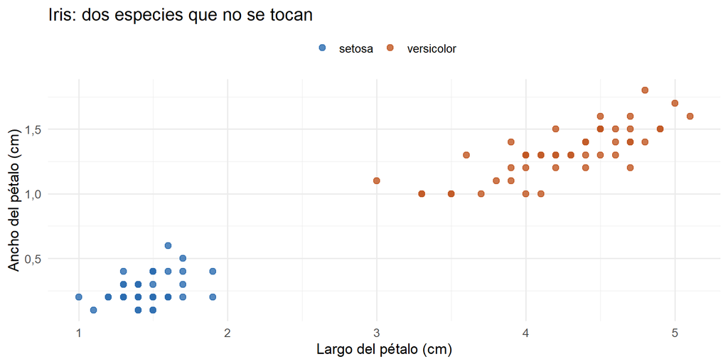

```r
ggplot(ir, aes(Petal.Length, Petal.Width, color = Species)) +
  geom_point(size = 2.4, alpha = 0.8) +
  scale_color_manual(values = c(setosa = "#2B6CB0", versicolor = "#C05621"), name = NULL) +
  scale_x_continuous(labels = function(x) coma(x, 0)) +
  scale_y_continuous(labels = function(x) coma(x, 1)) +
  labs(title = "Iris: dos especies que no se tocan",
       x = "Largo del pétalo (cm)", y = "Ancho del pétalo (cm)") +
  theme(legend.position = "top")
```

> 📋 **Describir:** entre *setosa* y *versicolor* la distancia es de 10,2 desviaciones, y con las cuatro medidas se acierta la especie en 100 de cada 100 flores.

> 🔎 **Analizar:** eso es **separación**: dos nubes que no se tocan. Comparen: el Atlántico estaba a 0,42 y hombres y mujeres a 0,49. **Decisión:** cuando un informe dice «los grupos son distintos», la pregunta siguiente es **¿como iris o como Saber?** La secretaría puede usar esta comparación en el informe para que nadie lea «distinto» como «separado».

# 8 Las tres preguntas, juntas

**La secretaría pregunta:** *«¿Qué ponemos en el informe?»*

```r
data.frame(
  comparacion = c("Antioquia frente al país", "Atlántico frente al país",
                  "Hombres frente a mujeres", "Setosa frente a versicolor (iris)"),
  es_real  = ifelse(c(h_ant["p"], h_atl["p"], h_gen["p"], h_iris[["p"]]) < 0.05, "sí", "no"),
  distancia_D = coma(c(h_ant["D"], h_atl["D"], h_gen["D"], h_iris[["D"]]), 2),
  separa = c("no", "no", "no", "sí")
)
```

| comparacion | es_real | distancia_D | separa |
| --- | --- | --- | --- |
| Antioquia frente al país | sí | 0,13 | no |
| Atlántico frente al país | sí | 0,42 | no |
| Hombres frente a mujeres | sí | 0,49 | no |
| Setosa frente a versicolor (iris) | sí | 10,16 | sí |

> 📋 **Describir:** las cuatro diferencias son reales. Las distancias van de 0,13 a 10,2, y solo iris separa.

> 🔎 **Analizar:** «es real» no distingue nada entre estos cuatro casos: los cuatro lo son. **Lo que distingue es la distancia y la separación.** **Decisión de la secretaría:** en el informe al gobernador van las tres respuestas, en este orden: ¿es real?, ¿es grande?, ¿separa? Y cada una con lo que se decide.

# 9 Qué no dice esta comparación

- **No dice por qué.** Que el Atlántico esté por debajo no dice que sus instituciones sean peores: vimos que el estrato viaja con el departamento.
- **No dice nada de un estudiante.** Compara promedios de grupos. Casi un tercio del Atlántico supera la mediana del país, y el mejor de estrato 1 supera a casi todo el país.
- **No es más importante por ser «más real».** Con 9 907 estudiantes, casi cualquier diferencia sale real. Lo que pesa es la distancia.

# 10 Cómo se llama lo que hicimos

Ya entendido todo, los nombres que van a encontrar en los libros y en los informes:

| Lo que hicimos | Cómo se llama |
| --- | --- |
| Medir la distancia entre promedios descontando que los módulos se mueven juntos | Distancia de Mahalanobis entre medias, $D$, usando la **matriz de covarianzas** |
| Preguntar si la distancia puede ser azar, con el tamaño del grupo | **Prueba T² de Hotelling**: multiplica la distancia al cuadrado por el tamaño del grupo |
| La probabilidad de ver esa distancia por azar | **Valor p** |
| Un grupo contra una referencia (el Atlántico contra el país) | Hotelling **de una muestra** |
| Dos grupos entre sí (hombres y mujeres) | Hotelling **de dos muestras** |
| Clasificar con los puntajes y contar aciertos | **Análisis discriminante** (`MASS::lda`) |

Para la secretaría, los valores exactos: en el Atlántico el T² es 109,0 con un valor p de $5{,}7 \times 10^{-20}$; en hombres y mujeres, T² = 588,0 con un valor p de $3{,}6 \times 10^{-121}$; en Antioquia, el valor p es $2{,}1 \times 10^{-4}$. En el código, las funciones `hotelling_1()` y `hotelling_2()` los calculan; úsenlas en el taller.

# 11 La puerta a lo que viene

Hoy comparamos **un grupo con el país** y **dos grupos entre sí**. El lunes 9 de noviembre la pregunta es con **cuatro grupos**: los estratos. Un programa de becas quiere saber si el estrato cambia el perfil completo o solo sube el nivel, y si separa o solo desplaza. La herramienta es la misma idea de hoy, extendida a varios grupos.

# 12 Preguntas de autoevaluación

1. ¿Por qué no basta con hacer cinco comparaciones, una por módulo?
2. ¿Qué le dice a la secretaría la distancia, y qué le dice la probabilidad de que sea azar? ¿Cuál de las dos le cambia una decisión?
3. Antioquia sale «distinta» del país. ¿Qué le diría al secretario de Antioquia si concluye que su departamento rinde mejor?
4. ¿Cómo puede haber una diferencia real entre hombres y mujeres y, al mismo tiempo, que los puntajes casi no sirvan para adivinar el sexo?
5. ¿Qué otra variable viaja con el departamento y podría explicar parte de la brecha del Atlántico? ¿Qué haría para comprobarlo?
6. ¿Cuál de estas afirmaciones es correcta? **(a)** Si es muy poco probable que una diferencia sea azar, la diferencia es grande. **(b)** Si dos grupos son distintos, se pueden separar. **(c)** Una diferencia puede ser real, pequeña y no separar a los grupos. **(d)** Esta comparación solo sirve para dos variables.

**Ver respuesta de la 6**

**(c).** Es exactamente el caso de Antioquia, y casi el de hombres y mujeres.

# 13 Conclusión: lo que le entregamos a la secretaría

- **Sí, el Atlántico rinde distinto del país**, y no es mala suerte: ningún grupo al azar del país llegó tan lejos. Está por debajo en los cinco módulos, a 0,42 desviaciones: una distancia moderada.
- **Parte viaja con el estrato**, pero no toda: dentro del mismo estrato la brecha sigue. El programa necesita dos frentes.
- **No separa a los estudiantes**: 31,5 de cada 100 superan la mediana del país. Sirve para diseñar un programa departamental, no para tratar a todos como si estuvieran abajo.
- **Hombres y mujeres tienen el mismo nivel y distinto perfil**: ventaja masculina en cuantitativo e inglés, femenina en escritura. Es real, pero los puntajes casi no separan a los grupos: el perfil sirve para prever la demanda del programa de orientación, y a cada estudiante se le orienta por sus propios puntajes, no por su sexo.

La pregunta que respondimos, y que cabe en cualquier informe de grupos: *¿es real?, ¿es grande?, ¿separa?*

# 14 Próxima clase

**Lunes 9 de noviembre · ¿El estrato cambia el perfil? (MANOVA).** Los primeros 20 minutos son para resolver las dudas de estas notas y del taller. Traigan sus preguntas anotadas.